# Modelo Zona Limpia: problema observado

Baseline XGBoost para estimar riesgo de problema observable en visitas efectivas

## Objetivo

Este reporte documenta el primer baseline de modelo para estimar la probabilidad de encontrar un problema observable si se visita un cluster con Zona Limpia.

El objetivo es distinto al del modelo COM operativo: aca no se busca predecir reclamos, sino aproximar un riesgo de problema observado en campo usando visitas efectivas de Zona Limpia.

## Definicion Del Target

El target del modelo es:

```
hay_zl_problema_comparable
```

El target vale `1` cuando Zona Limpia visito el cluster y observo un problema comparable, como `basura_fuera` o `contenedor_desbordado`.

COM no se usa como feature ni como target principal. Se conserva solo como evaluación secundaria para entender la relación entre el score ZL y los reclamos.

`Voluminosos` queda excluido del entrenamiento inicial porque no es comparable directamente con el problema COM usado en el modelo operativo.

## Universo De Entrenamiento

El universo inicial son visitas efectivas de Zona Limpia, excluyendo meses con cobertura anomala y registros no comparables.

Base observada por mes

| Mes | Filas | Positivos | Prevalencia | Clusters | Dias |
| --- | --- | --- | --- | --- | --- |
| 202510 | 16527 | 7714 | 46.7% | 6246 | 26 |
| 202511 | 21573 | 10565 | 49.0% | 6607 | 25 |
| 202512 | 22425 | 8952 | 39.9% | 6729 | 15 |
| 202603 | 14965 | 7511 | 50.2% | 4533 | 28 |
| 202604 | 28262 | 16510 | 58.4% | 6874 | 30 |
| 202605 | 22131 | 12097 | 54.7% | 6848 | 20 |

Decisiones principales del universo:

- meses usados: `202510`, `202511`, `202512`, `202603`, `202604`, `202605`;
- enero y febrero de 2026 quedan excluidos por cobertura anomala;
- Municipio B tiene cobertura incompleta en la fuente actual de Zona Limpia;
- el modelo aprende desde puntos observados por Zona Limpia, por lo que no debe interpretarse todavía como una estimación insesgada para toda la ciudad.

## Features

El baseline usa variables disponibles antes de la observacion del problema:

- variables operativas de levante y periodicidad con sufijo `_pred`;
- exceso positivo y exceso truncado a 7 días entre tiempo desde último levante y período teórico;
- variables censales y territoriales por cluster;
- municipio, CCZ y barrio asignados por centroide;
- variables calendario simples;
- feriados, vispera de feriado y día habil.

No se usan features COM como predictores.

## Diseno De Evaluación

- **Temporal**: train `202510-202512`, validación `202603`, test `202604-202605`.
- **Random por fila**: particion aleatoria de filas `cluster_id`/`dia`, preservando mes y target.
- **Random por día**: particion aleatoria de días completos dentro de cada mes.
- **Random por día repetido**: cinco repeticiones del split por día para medir sensibilidad a la semilla.

La evaluación temporal es la más exigente para uso operativo, porque mide generalizacion hacia meses posteriores. El random por fila sirve como techo optimista de senal aprendible. El random por día es una evaluación intermedia: mezcla meses, pero evita que clusters del mismo día queden repartidos entre train, validación y test.

Composicion de splits por escenario

| Escenario | Split | Filas | Positivos | Prevalencia | Clusters | Dias |
| --- | --- | --- | --- | --- | --- | --- |
| Random por dia | test | 23681 | 11793 | 49.8% | 7372 | 24 |
| Random por dia | train | 84219 | 42600 | 50.6% | 8093 | 99 |
| Random por dia | validacion | 17983 | 8956 | 49.8% | 6913 | 21 |
| Random por fila | test | 18888 | 9505 | 50.3% | 6825 | 142 |
| Random por fila | train | 88112 | 44341 | 50.3% | 8088 | 144 |
| Random por fila | validacion | 18883 | 9503 | 50.3% | 6837 | 143 |
| Temporal | test | 50393 | 28607 | 56.8% | 7448 | 50 |
| Temporal | train | 60525 | 27231 | 45.0% | 7499 | 66 |
| Temporal | validacion | 14965 | 7511 | 50.2% | 4533 | 28 |

Metricas por escenario y split

| Escenario | Split | N | Positivos | Prevalencia | AUC | Logloss |
| --- | --- | --- | --- | --- | --- | --- |
| Temporal | train | 60525 | 27231 | 45.0% | 0.713 | 0.618 |
| Temporal | validacion | 14965 | 7511 | 50.2% | 0.594 | 0.680 |
| Temporal | test | 50393 | 28607 | 56.8% | 0.602 | 0.690 |
| Random por fila | train | 88112 | 44341 | 50.3% | 0.695 | 0.634 |
| Random por fila | validacion | 18883 | 9503 | 50.3% | 0.679 | 0.642 |
| Random por fila | test | 18888 | 9505 | 50.3% | 0.677 | 0.643 |
| Random por dia | train | 84219 | 42600 | 50.6% | 0.699 | 0.632 |
| Random por dia | validacion | 17983 | 8956 | 49.8% | 0.676 | 0.643 |
| Random por dia | test | 23681 | 11793 | 49.8% | 0.660 | 0.653 |

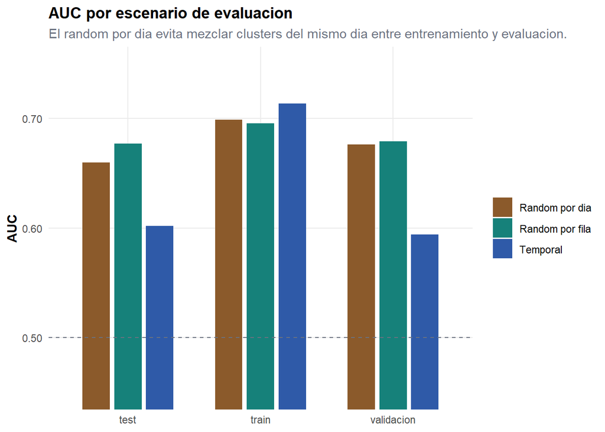

Random por dia repetido: sensibilidad a la semilla

| Split | Reps | AUC min | AUC mediana | AUC max | Logloss mediana |
| --- | --- | --- | --- | --- | --- |
| validacion | 5 | 0.629 | 0.664 | 0.670 | 0.650 |
| test | 5 | 0.663 | 0.669 | 0.681 | 0.647 |

## Sensibilidad Del Target

El score se entrena con el target principal `ZL problema comparable`. Como diagnóstico, se evalua el mismo score contra variantes del target. Esto no reentrena modelos alternativos, pero ayuda a leer que senal está capturando.

Evaluacion del mismo score contra targets alternativos

| Escenario | Split | Target evaluado | N | Positivos | Prevalencia | AUC |
| --- | --- | --- | --- | --- | --- | --- |
| Temporal | validacion | ZL problema comparable | 14965 | 7511 | 50.2% | 0.594 |
| Temporal | test | ZL problema comparable | 50393 | 28607 | 56.8% | 0.602 |
| Random por fila | validacion | ZL problema comparable | 18883 | 9503 | 50.3% | 0.679 |
| Random por fila | test | ZL problema comparable | 18888 | 9505 | 50.3% | 0.677 |
| Random por dia | validacion | ZL problema comparable | 17983 | 8956 | 49.8% | 0.676 |
| Random por dia | test | ZL problema comparable | 23681 | 11793 | 49.8% | 0.660 |
| Temporal | validacion | COM OR ZL problema | 14965 | 8001 | 53.5% | 0.595 |
| Temporal | test | COM OR ZL problema | 50393 | 30378 | 60.3% | 0.594 |
| Random por fila | validacion | COM OR ZL problema | 18883 | 10198 | 54.0% | 0.668 |
| Random por fila | test | COM OR ZL problema | 18888 | 10220 | 54.1% | 0.670 |
| Random por dia | validacion | COM OR ZL problema | 17983 | 9646 | 53.6% | 0.663 |
| Random por dia | test | COM OR ZL problema | 23681 | 12668 | 53.5% | 0.651 |
| Temporal | validacion | COM | 14965 | 1141 | 7.6% | 0.559 |
| Temporal | test | COM | 50393 | 4869 | 9.7% | 0.484 |
| Random por fila | validacion | COM | 18883 | 1750 | 9.3% | 0.529 |
| Random por fila | test | COM | 18888 | 1801 | 9.5% | 0.533 |
| Random por dia | validacion | COM | 17983 | 1635 | 9.1% | 0.529 |
| Random por dia | test | COM | 23681 | 2034 | 8.6% | 0.507 |
| Temporal | validacion | Solo ZL sin COM | 14965 | 6860 | 45.8% | 0.578 |
| Temporal | test | Solo ZL sin COM | 50393 | 25509 | 50.6% | 0.595 |
| Random por fila | validacion | Solo ZL sin COM | 18883 | 8448 | 44.7% | 0.658 |
| Random por fila | test | Solo ZL sin COM | 18888 | 8419 | 44.6% | 0.659 |
| Random por dia | validacion | Solo ZL sin COM | 17983 | 8011 | 44.5% | 0.654 |
| Random por dia | test | Solo ZL sin COM | 23681 | 10634 | 44.9% | 0.650 |

## Lift Operativo

El lift ayuda a leer si el ranking concentra problemas en los clusters de mayor score. Para cada split se ordenan los clusters por `pred_prob` y se toma el top 5%, 10%, 20% y 30%.

- **Precisión**: dentro del top seleccionado, que porcentaje tenia problema ZL.
- **Captura**: que porcentaje de todos los problemas ZL del split queda dentro de ese top.
- **Lift**: precisión del top dividida por la prevalencia del split.

La comparación natural no es contra 100%, sino contra la prevalencia base. Por ejemplo, si la prevalencia del split es 50% y el top 5% tiene precisión 75%, el lift es `1,5`: el top seleccionado tiene 50% más densidad de problemas que una selección aleatoria del mismo tamano.

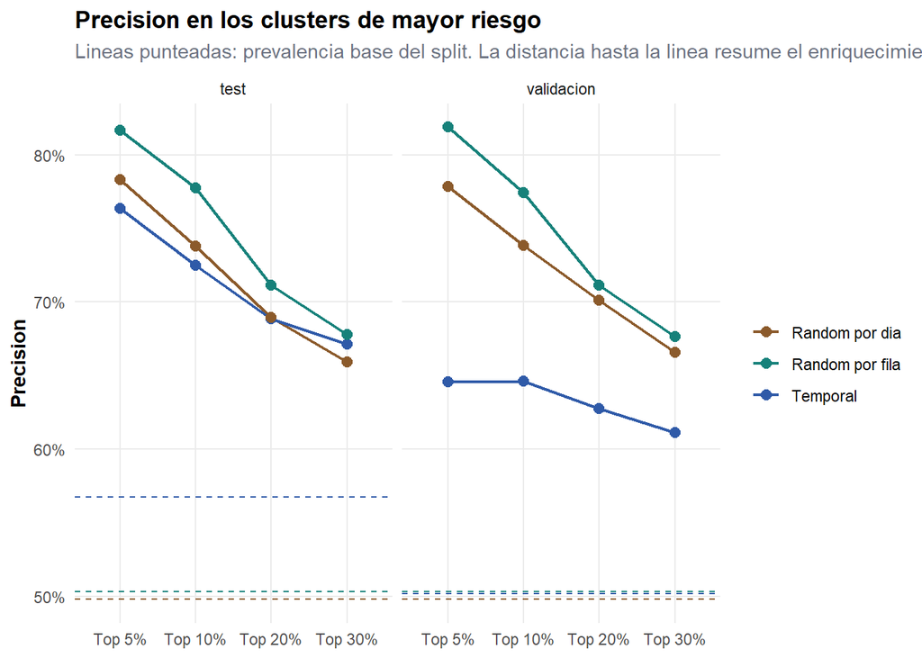

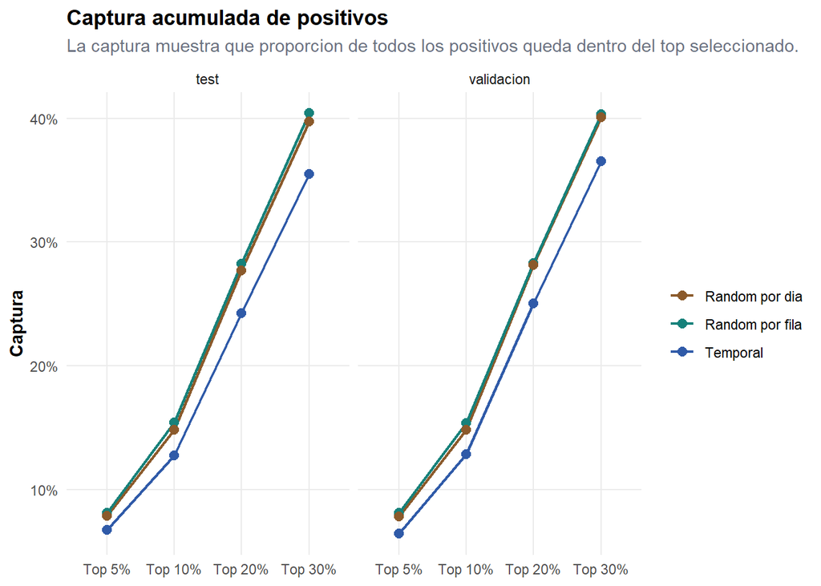

Lift operativo por top seleccionado

| Escenario | Split | Top | N | Positivos | Precision | Captura | Lift |
| --- | --- | --- | --- | --- | --- | --- | --- |
| Temporal | validacion | Top 5% | 748 | 483 | 64.6% | 6.4% | 1.29 |
| Temporal | validacion | Top 10% | 1496 | 967 | 64.6% | 12.9% | 1.29 |
| Temporal | validacion | Top 20% | 2993 | 1879 | 62.8% | 25.0% | 1.25 |
| Temporal | validacion | Top 30% | 4489 | 2744 | 61.1% | 36.5% | 1.22 |
| Temporal | test | Top 5% | 2519 | 1923 | 76.3% | 6.7% | 1.34 |
| Temporal | test | Top 10% | 5039 | 3652 | 72.5% | 12.8% | 1.28 |
| Temporal | test | Top 20% | 10078 | 6938 | 68.8% | 24.3% | 1.21 |
| Temporal | test | Top 30% | 15117 | 10148 | 67.1% | 35.5% | 1.18 |
| Random por fila | validacion | Top 5% | 944 | 773 | 81.9% | 8.1% | 1.63 |
| Random por fila | validacion | Top 10% | 1888 | 1462 | 77.4% | 15.4% | 1.54 |
| Random por fila | validacion | Top 20% | 3776 | 2687 | 71.2% | 28.3% | 1.41 |
| Random por fila | validacion | Top 30% | 5664 | 3831 | 67.6% | 40.3% | 1.34 |
| Random por fila | test | Top 5% | 944 | 771 | 81.7% | 8.1% | 1.62 |
| Random por fila | test | Top 10% | 1888 | 1468 | 77.8% | 15.4% | 1.55 |
| Random por fila | test | Top 20% | 3777 | 2686 | 71.1% | 28.3% | 1.41 |
| Random por fila | test | Top 30% | 5666 | 3842 | 67.8% | 40.4% | 1.35 |
| Random por dia | validacion | Top 5% | 899 | 700 | 77.9% | 7.8% | 1.56 |
| Random por dia | validacion | Top 10% | 1798 | 1328 | 73.9% | 14.8% | 1.48 |
| Random por dia | validacion | Top 20% | 3596 | 2521 | 70.1% | 28.1% | 1.41 |
| Random por dia | validacion | Top 30% | 5394 | 3592 | 66.6% | 40.1% | 1.34 |
| Random por dia | test | Top 5% | 1184 | 927 | 78.3% | 7.9% | 1.57 |
| Random por dia | test | Top 10% | 2368 | 1747 | 73.8% | 14.8% | 1.48 |
| Random por dia | test | Top 20% | 4736 | 3265 | 68.9% | 27.7% | 1.38 |
| Random por dia | test | Top 30% | 7104 | 4684 | 65.9% | 39.7% | 1.32 |

## Variables Importantes

La importancia se reporta como importancia interna del XGBoost. Sirve como diagnóstico inicial, no como interpretación causal.

[figure not shown]

## Lectura Inicial

La evaluación random por fila muestra AUC cercano a `0,68` en validación y test. Esto sugiere que existe senal aprendible en las variables disponibles, aunque este escenario puede ser optimista porque mezcla clusters de un mismo día entre train y evaluación.

La evaluación random por día mantiene días completos fuera del entrenamiento. El AUC queda cerca de `0,68` en validación y cerca de `0,66` en test. Esto indica que parte de la senal se sostiene cuando no se mezcla el contexto diario, aunque hay una baja respecto al random por fila.

Las repeticiones del random por día muestran que el AUC test se mueve aproximadamente entre `0,663` y `0,681`. Esto confirma que la lectura depende de la composicion de días, pero que el resultado está claramente por encima del split temporal.

La evaluación temporal cae a AUC cercano a `0,60`. Esa caida es importante: indica que el baseline todavía no generaliza de forma robusta cuando se entrena en fines de 2025 y se evalua en 2026. Las causas posibles incluyen cambios de criterio operativo, diferencias de cobertura, estacionalidad, cambios de registro o selección no aleatoria de visitas.

La sensibilidad de targets sugiere que el score ZL no captura reclamos COM puros con la misma fuerza. En random por día test, el AUC contra COM queda cerca de `0,51`, mientras que contra el target hibrido `COM OR ZL problema` queda cerca de `0,65`.

Por ahora, este modelo debe leerse como baseline exploratorio. No alcanza para reemplazar una regla operativa, pero si deja un punto de comparación concreto para nuevas features, nuevos targets y evaluaciones con sesgo de selección.

## Limitaciones

- El modelo se entrena solo sobre visitas efectivas de Zona Limpia.
- Municipio B tiene cobertura incompleta en la fuente actual.
- La selección de Zona Limpia no es aleatoria y puede concentrar lugares con mayor riesgo.
- COM no entra al target principal, pero sigue siendo una fuente relevante para evaluación cruzada y comparación con el modelo de reclamos.
- Las métricas temporales muestran estabilidad limitada.

## Proximos Pasos

- Reentrenar o reevaluar cuando se integre la fuente faltante de Municipio B.
- Comparar contra ajustes por propensión de visita.
- Profundizar calibración y estabilidad diaria antes de usarlo como insumo operativo.
- Evaluar si nuevas fuentes externas, como lluvia disponible ex ante, agregan senal.
- Mantener separada la lectura de reclamos COM y la lectura de problema observado.